# New Module:

## `qiskit.algorithms.state_fidelities`

*Qiskit Demo Day (September 15, 2022)*

Elena Peña Tapia

## Index

1. Introduction
2. Module Overview
3. `ComputeUncompute` Explanation
4. `ComputeUncompute` Example
5. Wrap-Up

## 1. Introduction

- `qiskit.algorithms.state_fidelities`, part of `qiskit-terra 0.22`
- Interfaces for Fidelity/State Overlap of **pairs of (parametrized) quantum circuits**
- Used in Quantum Kernels, VQD, PVQD, QNSPSA optimizer....
- Leverages the new `primitives`

$ statefidelity = |\langle\psi(x)|\phi(y)\rangle|^2 $

## Side Note: Sampler interface

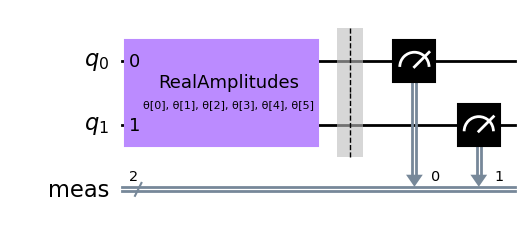

```python
from qiskit.circuit.library import RealAmplitudes

# Build circuit
qc = RealAmplitudes(num_qubits=2, reps=2) # 6 parameters
qc.measure_all()
qc.draw(output='mpl')
```

```python
# Define parameter sets
theta1 = [0, 1, 1, 2, 3, 5]
theta2 = [1, 2, 3, 4, 5, 6]
```

```python
from qiskit.primitives import Sampler
sampler = Sampler()

# submit sampler job
job = sampler.run(circuits = [qc, qc], parameter_values = [theta1, theta2])

# retrieve sampler result
quasi_dists =  job.result().quasi_dists

# print result
for (i,q) in enumerate(quasi_dists):
    print(f"result theta{i+1}", q)
```

```
result theta1 {0: 0.1309248462975777, 1: 0.3608720796028448, 2: 0.09324865232050054, 3: 0.41495442177907715}
result theta2 {0: 0.06282290651933871, 1: 0.02877144385576705, 2: 0.606654494132085, 3: 0.3017511554928094}
```

## 2. Module contents

- `BaseStateFidelity`
- `StateFidelityResult`
- `ComputeUncompute` --> new methods will be added in the future: `HadamardTest`, `SwapTest`...

```python
class BaseStateFidelity(ABC):
    ...
    def run(
        self,
        circuits_1: QuantumCircuit   | Sequence[QuantumCircuit],
        circuits_2: QuantumCircuit   | Sequence[QuantumCircuit],
        values_1:   Sequence[float]  | Sequence[Sequence[float]] | None = None,
        values_2:   Sequence[float]  | Sequence[Sequence[float]] | None = None,
        **options,
    ) -> AlgorithmJob:
        ...

    def _run(
        ...
    ) -> StateFidelityResult:
        ...
```

```python
class StateFidelityResult:
    """This class stores the result of StateFidelity computations."""

    fidelities: Sequence[float]
    """List of truncated fidelity values for each pair of input circuits, ensured to be in [0,1]."""
    raw_fidelities: Sequence[float]
    """List of raw fidelity values for each pair of input circuits, which might not be in [0,1]
    depending on the error mitigation method used."""
    metadata: Sequence[Mapping[str, Any]]
    """Additional information about the fidelity calculation."""
    options: Options
    """Primitive runtime options for the execution of the fidelity job."""
```

## 3. `ComputeUncompute` method to calculate state fidelity

**Reminder of Definition:**

$ statefidelity = |\langle\psi(x)|\phi(y)\rangle|^2 $

**Compute-Uncompute Method [1]:**

1. Construct circuit: unitary of 1st state & inverse unitary of 2nd
2. Measure all qubits
3. Get frequency of "all-zero" outcome (|0000...>) --> **State Fidelity**

*[1] Havlíček, V., Córcoles, A. D., Temme, K., Harrow, A. W., Kandala, A., Chow, J. M., & Gambetta, J. M. (2019). Supervised learning with quantum-enhanced feature spaces. Nature, 567(7747), 209-212. arXiv:1804.11326v2*

```python
class ComputeUncompute(BaseStateFidelity):
        ...

    def create_fidelity_circuit(
        self,
        circuit_1: QuantumCircuit,
        circuit_2: QuantumCircuit ) -> QuantumCircuit:

        circuit = circuit_1.compose(circuit_2.inverse())
        circuit.measure_all()

        return circuit

    def _run(...):

        # Construct fidelity circuits --> circuits
        # Construct parameter value lists --> values

        job = self._sampler.run(circuits=circuits, parameter_values=values, **opt)

        raw_fidelities = [prob_dist.get(0, 0) for prob_dist in job.result().quasi_dists]

        fidelities = self._truncate_fidelities(raw_fidelities)
```

## 4. `ComputeUncompute` Examples

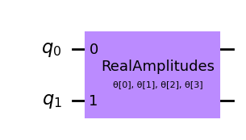

```python
# Build circuit
qc1 = RealAmplitudes(num_qubits=2, reps=1) # 4 parameters
qc1.draw(output='mpl')
```

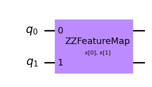

```python
from qiskit.circuit.library import ZZFeatureMap

qc2 = ZZFeatureMap(2, reps =1) # 2 parameters
qc2.draw(output='mpl')
```

```python
# instantiate fidelity
from qiskit.algorithms.state_fidelities import ComputeUncompute

fidelity = ComputeUncompute(sampler=Sampler())
```

### Example without batching

```python
# define param. values
values1 = [1,2,3,4]
values2 = [7,8]

# run job
job_1 = fidelity.run(qc1, qc2, values1, values2)

# retrieve results
results_1 = job_1.result().fidelities
print(results_1)
```

```
[0.2550267968270442]
```

### Example with batching

```python
# define param. values
values1 = [[1,2,3,4], [4,3,2,1], [0,0,0,0]]
values2 = [[7,8], [1,2], [3,4]]

# run job
job_2 = fidelity.run([qc1]*3, [qc2]*3, values1, values2)

# retrieve results
results_2 = job_2.result().fidelities
print(results_2)
```

```
[0.2550267968270442, 0.03806566537280539, 0.2499999999999999]
```

### More examples

```python
# Non-parametrized quantum circuit
qc3 = QuantumCircuit(2)
qc3.h(1)

# run job
job_3 = fidelity.run(qc3, qc2, None, [1,2])

# retrieve results
results_3 = job_3.result().fidelities
print(results_3)
```

```
[0.03494878710943565]
```

# 5. Wrap-Up

- New State Fidelity interfaces in `qiskit-terra 0.22`
- They compute overlaps of pairs of (parametrized) quantum circuits
- `ComputeUncompute` method based on `Sampler`
- Will be integrated in new algorithms using primtives